# Project: No-Show Appointments Data Analysis

- Introduction
- Data Wrangling
- Exploratory Data Analysis
- Conclusions

## Introduction

*No-show appointments dataset is a collection of information from 100k medical appointments in Brazil and is focused on the question of whether or not patients show up for their appointment. The dataset capture the information about patient's age, gender, medical history (diabetes, hipertension, etc.), and lifestyle (alcoholism, etc.) with complete appointment details and has a final indicater that whether a patient showed up on the day of appointment or not. Each patient is allocated with a patientID.*

### Questions to be investigated:

1. Does age play a role that whether or not patient show up for their appointment?
2. How does patient's medical history, lifestyle, physical fitness affects appointments?
3. Which neighborhoods have the highest number of no-shows?
4. What is the trend of no-shows vs shows by patients that received SMS reminders?
5. Does difference between schedule date and appointment date results in no-shows?
6. Are patients failing to appear on specific days of the week?
7. Which gender group generally don't show-up on appointment day ?

```python
# set up import statements for all of the packages
import pandas as pd
import numpy as np
import datetime as dt
import matplotlib.pyplot as plt
import seaborn as sns
import warnings
warnings.filterwarnings('ignore')

% matplotlib inline
sns.set_style('darkgrid')
# visualizations see this page for more: http://ipython.readthedocs.io/en/stable/interactive/magics.html
```

## Data Wrangling

In this section of the report, we will load in the data, check for cleanliness, and then trim and clean dataset for analysis.

### General Properties

```python
# Load data and see what is there.
df = pd.read_csv("noshowappointments-kagglev2-may-2016.csv")
df.head()
```

|  | PatientId | AppointmentID | Gender | ScheduledDay | AppointmentDay | Age | Neighbourhood | Scholarship | Hipertension | Diabetes | Alcoholism | Handcap | SMS_received | No-show |
| --- | --- | --- | --- | --- | --- | --- | --- | --- | --- | --- | --- | --- | --- | --- |
| 0 | 2.987250e+13 | 5642903 | F | 2016-04-29T18:38:08Z | 2016-04-29T00:00:00Z | 62 | JARDIM DA PENHA | 0 | 1 | 0 | 0 | 0 | 0 | No |
| 1 | 5.589978e+14 | 5642503 | M | 2016-04-29T16:08:27Z | 2016-04-29T00:00:00Z | 56 | JARDIM DA PENHA | 0 | 0 | 0 | 0 | 0 | 0 | No |
| 2 | 4.262962e+12 | 5642549 | F | 2016-04-29T16:19:04Z | 2016-04-29T00:00:00Z | 62 | MATA DA PRAIA | 0 | 0 | 0 | 0 | 0 | 0 | No |
| 3 | 8.679512e+11 | 5642828 | F | 2016-04-29T17:29:31Z | 2016-04-29T00:00:00Z | 8 | PONTAL DE CAMBURI | 0 | 0 | 0 | 0 | 0 | 0 | No |
| 4 | 8.841186e+12 | 5642494 | F | 2016-04-29T16:07:23Z | 2016-04-29T00:00:00Z | 56 | JARDIM DA PENHA | 0 | 1 | 1 | 0 | 0 | 0 | No |

```python
# Perform operations to inspect datatypes
# and look for instances of missing or possibly errant data.
df.info()
```

```
<class 'pandas.core.frame.DataFrame'>
RangeIndex: 110527 entries, 0 to 110526
Data columns (total 14 columns):
PatientId         110527 non-null float64
AppointmentID     110527 non-null int64
Gender            110527 non-null object
ScheduledDay      110527 non-null object
AppointmentDay    110527 non-null object
Age               110527 non-null int64
Neighbourhood     110527 non-null object
Scholarship       110527 non-null int64
Hipertension      110527 non-null int64
Diabetes          110527 non-null int64
Alcoholism        110527 non-null int64
Handcap           110527 non-null int64
SMS_received      110527 non-null int64
No-show           110527 non-null object
dtypes: float64(1), int64(8), object(5)
memory usage: 11.8+ MB
```

```python
print(sum(df.duplicated()))
```

```
0
```

```python
df.describe()
```

|  | PatientId | AppointmentID | Age | Scholarship | Hipertension | Diabetes | Alcoholism | Handcap | SMS_received |
| --- | --- | --- | --- | --- | --- | --- | --- | --- | --- |
| count | 1.105270e+05 | 1.105270e+05 | 110527.000000 | 110527.000000 | 110527.000000 | 110527.000000 | 110527.000000 | 110527.000000 | 110527.000000 |
| mean | 1.474963e+14 | 5.675305e+06 | 37.088874 | 0.098266 | 0.197246 | 0.071865 | 0.030400 | 0.022248 | 0.321026 |
| std | 2.560949e+14 | 7.129575e+04 | 23.110205 | 0.297675 | 0.397921 | 0.258265 | 0.171686 | 0.161543 | 0.466873 |
| min | 3.921784e+04 | 5.030230e+06 | -1.000000 | 0.000000 | 0.000000 | 0.000000 | 0.000000 | 0.000000 | 0.000000 |
| 25% | 4.172614e+12 | 5.640286e+06 | 18.000000 | 0.000000 | 0.000000 | 0.000000 | 0.000000 | 0.000000 | 0.000000 |
| 50% | 3.173184e+13 | 5.680573e+06 | 37.000000 | 0.000000 | 0.000000 | 0.000000 | 0.000000 | 0.000000 | 0.000000 |
| 75% | 9.439172e+13 | 5.725524e+06 | 55.000000 | 0.000000 | 0.000000 | 0.000000 | 0.000000 | 0.000000 | 1.000000 |
| max | 9.999816e+14 | 5.790484e+06 | 115.000000 | 1.000000 | 1.000000 | 1.000000 | 1.000000 | 4.000000 | 1.000000 |

```python
df.shape
```

```
(110527, 14)
```

#### Observations:

- *Changing column case and using underscores will make columns easier to read and work with*
- *Changing column mispellings will make columns easier to read and work with*
- *Changing patientID data type from float to int will make the dataset easier to work with*
- *Stripping time from the schedule day column will make the dataset easier to work with*
- *Stripping time from the appointment day column will make the dataset easier to work with*
- *No duplicate data exists*
- *Minimum Age appears as -1. Any such patient will be assumed to be a newborn or infant.*

### Data Cleaning

After observing the structure of the data in this section we will perform cleaning steps

```python
# STEP 1: Fix mispellings, underscores, and case
new_labels = ['patientID', 'appointmentID', 'gender', 'schedule_day', 'appointment_day', 'age', 'neighborhood', 'scholarship', 'hypertension', 'diabetes', 'alcoholism', 'handicap', 'sms_received', 'no_show']
df.columns = new_labels
df.head()
```

|  | patientID | appointmentID | gender | schedule_day | appointment_day | age | neighborhood | scholarship | hypertension | diabetes | alcoholism | handicap | sms_received | no_show |
| --- | --- | --- | --- | --- | --- | --- | --- | --- | --- | --- | --- | --- | --- | --- |
| 0 | 2.987250e+13 | 5642903 | F | 2016-04-29T18:38:08Z | 2016-04-29T00:00:00Z | 62 | JARDIM DA PENHA | 0 | 1 | 0 | 0 | 0 | 0 | No |
| 1 | 5.589978e+14 | 5642503 | M | 2016-04-29T16:08:27Z | 2016-04-29T00:00:00Z | 56 | JARDIM DA PENHA | 0 | 0 | 0 | 0 | 0 | 0 | No |
| 2 | 4.262962e+12 | 5642549 | F | 2016-04-29T16:19:04Z | 2016-04-29T00:00:00Z | 62 | MATA DA PRAIA | 0 | 0 | 0 | 0 | 0 | 0 | No |
| 3 | 8.679512e+11 | 5642828 | F | 2016-04-29T17:29:31Z | 2016-04-29T00:00:00Z | 8 | PONTAL DE CAMBURI | 0 | 0 | 0 | 0 | 0 | 0 | No |
| 4 | 8.841186e+12 | 5642494 | F | 2016-04-29T16:07:23Z | 2016-04-29T00:00:00Z | 56 | JARDIM DA PENHA | 0 | 1 | 1 | 0 | 0 | 0 | No |

```python
# STEP 2: Convert schedule_day field from string to datetime
df['schedule_day'] = pd.to_datetime(df['schedule_day'])
df.info()
```

```
<class 'pandas.core.frame.DataFrame'>
RangeIndex: 110527 entries, 0 to 110526
Data columns (total 14 columns):
patientID          110527 non-null float64
appointmentID      110527 non-null int64
gender             110527 non-null object
schedule_day       110527 non-null datetime64[ns]
appointment_day    110527 non-null object
age                110527 non-null int64
neighborhood       110527 non-null object
scholarship        110527 non-null int64
hypertension       110527 non-null int64
diabetes           110527 non-null int64
alcoholism         110527 non-null int64
handicap           110527 non-null int64
sms_received       110527 non-null int64
no_show            110527 non-null object
dtypes: datetime64[ns](1), float64(1), int64(8), object(4)
memory usage: 11.8+ MB
```

```python
# STEP 3: Ignoring the time portion of schedule_day because no time data exists
df['schedule_day'] = df['schedule_day'].apply(lambda x: x.strftime('%m-%d-%Y'))
df.info()
```

```
<class 'pandas.core.frame.DataFrame'>
RangeIndex: 110527 entries, 0 to 110526
Data columns (total 14 columns):
patientID          110527 non-null float64
appointmentID      110527 non-null int64
gender             110527 non-null object
schedule_day       110527 non-null object
appointment_day    110527 non-null object
age                110527 non-null int64
neighborhood       110527 non-null object
scholarship        110527 non-null int64
hypertension       110527 non-null int64
diabetes           110527 non-null int64
alcoholism         110527 non-null int64
handicap           110527 non-null int64
sms_received       110527 non-null int64
no_show            110527 non-null object
dtypes: float64(1), int64(8), object(5)
memory usage: 11.8+ MB
```

```python
# STEP 4: Convert appoint_day field from string to datetime
df['appointment_day'] = pd.to_datetime(df['appointment_day'])
df.info()
```

```
<class 'pandas.core.frame.DataFrame'>
RangeIndex: 110527 entries, 0 to 110526
Data columns (total 14 columns):
patientID          110527 non-null float64
appointmentID      110527 non-null int64
gender             110527 non-null object
schedule_day       110527 non-null object
appointment_day    110527 non-null datetime64[ns]
age                110527 non-null int64
neighborhood       110527 non-null object
scholarship        110527 non-null int64
hypertension       110527 non-null int64
diabetes           110527 non-null int64
alcoholism         110527 non-null int64
handicap           110527 non-null int64
sms_received       110527 non-null int64
no_show            110527 non-null object
dtypes: datetime64[ns](1), float64(1), int64(8), object(4)
memory usage: 11.8+ MB
```

```python
# STEP 5: Ignoring the time portion of appointment_day to keep value uniform with schedule_day
df['appointment_day'] = df['appointment_day'].apply(lambda x: x.strftime('%m-%d-%Y'))
df.info()
```

```
<class 'pandas.core.frame.DataFrame'>
RangeIndex: 110527 entries, 0 to 110526
Data columns (total 14 columns):
patientID          110527 non-null float64
appointmentID      110527 non-null int64
gender             110527 non-null object
schedule_day       110527 non-null object
appointment_day    110527 non-null object
age                110527 non-null int64
neighborhood       110527 non-null object
scholarship        110527 non-null int64
hypertension       110527 non-null int64
diabetes           110527 non-null int64
alcoholism         110527 non-null int64
handicap           110527 non-null int64
sms_received       110527 non-null int64
no_show            110527 non-null object
dtypes: float64(1), int64(8), object(5)
memory usage: 11.8+ MB
```

```python
# STEP 6: Created a appointment_dow column for day of week analysis

df['schedule_day'] = pd.to_datetime(df['schedule_day'])
df['appointment_day'] = pd.to_datetime(df['appointment_day'])

df['schedule_dow'] = df['schedule_day'].dt.weekday_name
df['appointment_dow'] = df['appointment_day'].dt.weekday_name
df.head()
```

|  | patientID | appointmentID | gender | schedule_day | appointment_day | age | neighborhood | scholarship | hypertension | diabetes | alcoholism | handicap | sms_received | no_show | schedule_dow | appointment_dow |
| --- | --- | --- | --- | --- | --- | --- | --- | --- | --- | --- | --- | --- | --- | --- | --- | --- |
| 0 | 2.987250e+13 | 5642903 | F | 2016-04-29 | 2016-04-29 | 62 | JARDIM DA PENHA | 0 | 1 | 0 | 0 | 0 | 0 | No | Friday | Friday |
| 1 | 5.589978e+14 | 5642503 | M | 2016-04-29 | 2016-04-29 | 56 | JARDIM DA PENHA | 0 | 0 | 0 | 0 | 0 | 0 | No | Friday | Friday |
| 2 | 4.262962e+12 | 5642549 | F | 2016-04-29 | 2016-04-29 | 62 | MATA DA PRAIA | 0 | 0 | 0 | 0 | 0 | 0 | No | Friday | Friday |
| 3 | 8.679512e+11 | 5642828 | F | 2016-04-29 | 2016-04-29 | 8 | PONTAL DE CAMBURI | 0 | 0 | 0 | 0 | 0 | 0 | No | Friday | Friday |
| 4 | 8.841186e+12 | 5642494 | F | 2016-04-29 | 2016-04-29 | 56 | JARDIM DA PENHA | 0 | 1 | 1 | 0 | 0 | 0 | No | Friday | Friday |

```python
# STEP 7: Changed patiendID data type from float to int
df['patientID'] = df['patientID'].astype(int)
df.info()
```

```
<class 'pandas.core.frame.DataFrame'>
RangeIndex: 110527 entries, 0 to 110526
Data columns (total 16 columns):
patientID          110527 non-null int64
appointmentID      110527 non-null int64
gender             110527 non-null object
schedule_day       110527 non-null datetime64[ns]
appointment_day    110527 non-null datetime64[ns]
age                110527 non-null int64
neighborhood       110527 non-null object
scholarship        110527 non-null int64
hypertension       110527 non-null int64
diabetes           110527 non-null int64
alcoholism         110527 non-null int64
handicap           110527 non-null int64
sms_received       110527 non-null int64
no_show            110527 non-null object
schedule_dow       110527 non-null object
appointment_dow    110527 non-null object
dtypes: datetime64[ns](2), int64(9), object(5)
memory usage: 13.5+ MB
```

```python
# STEP 8: Transformed the data type of the no_show field to integer
df["no_show"] = np.where((df.no_show=="Yes"), 1, 0)
df.head()
```

|  | patientID | appointmentID | gender | schedule_day | appointment_day | age | neighborhood | scholarship | hypertension | diabetes | alcoholism | handicap | sms_received | no_show | schedule_dow | appointment_dow |
| --- | --- | --- | --- | --- | --- | --- | --- | --- | --- | --- | --- | --- | --- | --- | --- | --- |
| 0 | 29872499824296 | 5642903 | F | 2016-04-29 | 2016-04-29 | 62 | JARDIM DA PENHA | 0 | 1 | 0 | 0 | 0 | 0 | 0 | Friday | Friday |
| 1 | 558997776694438 | 5642503 | M | 2016-04-29 | 2016-04-29 | 56 | JARDIM DA PENHA | 0 | 0 | 0 | 0 | 0 | 0 | 0 | Friday | Friday |
| 2 | 4262962299951 | 5642549 | F | 2016-04-29 | 2016-04-29 | 62 | MATA DA PRAIA | 0 | 0 | 0 | 0 | 0 | 0 | 0 | Friday | Friday |
| 3 | 867951213174 | 5642828 | F | 2016-04-29 | 2016-04-29 | 8 | PONTAL DE CAMBURI | 0 | 0 | 0 | 0 | 0 | 0 | 0 | Friday | Friday |
| 4 | 8841186448183 | 5642494 | F | 2016-04-29 | 2016-04-29 | 56 | JARDIM DA PENHA | 0 | 1 | 1 | 0 | 0 | 0 | 0 | Friday | Friday |

## Exploratory Data Analysis

Compute statistics and create visualizations with the goal of addressing the research questions that are posed in the Introduction section.

### Derived columns for answer the research questions

```python
# time between schedule and appointment dates
df['elapsed_days'] = df['appointment_day'] - df['schedule_day']
```

```python
# all no-show records
all_no_shows = df.query('no_show == "1"')
```

```python
# all show records
all_shows = df.query('no_show == "0"')
```

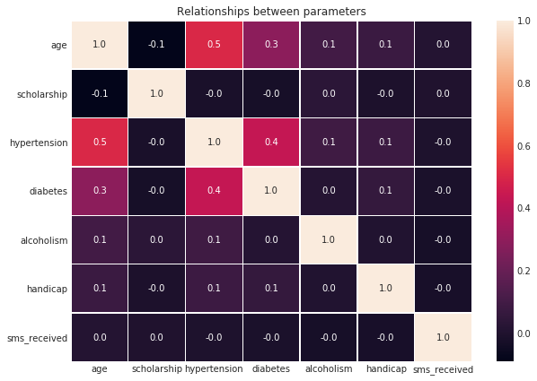

```python
# correlation map to show relationships between parameters/variables
f,ax = plt.subplots(figsize=(10, 7))
_extracted_df = df.loc[:,"age":"sms_received"]
sns.heatmap(_extracted_df.corr(), annot=True, linewidths=.5, fmt= '.1f',ax=ax)
plt.title("Relationships between parameters")
plt.show()
```

##### Correlation map to show relationships between parameters/variables. From the above map we can observe the following:

1. Age are positively realted with hypertension (0.5), and with diabeties (0.3)
2. Hypertension is related with the diabeties (0.4) which shows that patients who has diabeties are likely to have hypretension (vice-versa).

### Question 1: Does age play a role that whether or not patient show up for their appointment?

#### Distribution of age for no-show and show appointments

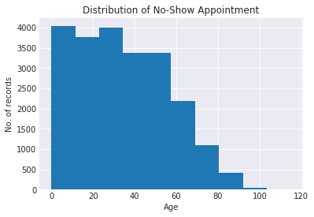

```python
# Distribution of age for no-show appointments
df_age_no_show = all_no_shows['age']
df_age_no_show.hist()
plt.title("Distribution of No-Show Appointment")
plt.xlabel('Age')
plt.ylabel('No. of records')
plt.show()
```

> We see the downward trend after ~58 age.

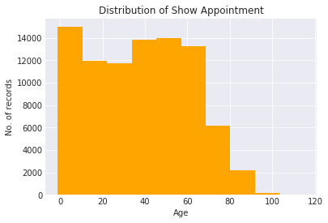

```python
# Distribution of age for show appointments
df_age_show = all_shows['age']
df_age_show.hist(color='orange')
plt.title("Distribution of Show Appointment")
plt.xlabel('Age')
plt.ylabel('No. of records')
plt.show()
```

> People between the age group of around 35-40 to 65-70 shows up for appointments, as we can see the increase in records.

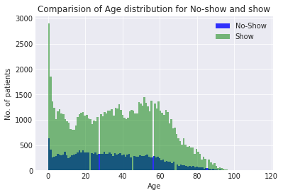

```python
# Comparision between show and no-show appointments
df_age_no_show.plot.hist(bins=120, color='blue',alpha = 0.8, label='No-Show')
df_age_show.plot.hist(bins=120, color='green', alpha = 0.5, label='Show')
plt.legend()
plt.title('Comparision of Age distribution for No-show and show')
plt.xlabel('Age')
plt.ylabel('No. of patients')
plt.show()
```

> Comparision between show and no-show appointments can be well understand from the above graph.

#### Statistics for age distribution

```python
# Mean values
print("Mean values for: ")
print("No-Show: ", df_age_no_show.mean(), " Show: ", df_age_show.mean())
```

```
Mean values for:
No-Show:  34.3176665621  Show:  37.7900643933
```

```python
# Total count
print("Total count: ")
print("No-Show: ", df_age_no_show.count(), " Show: ", df_age_show.count())
```

```
Total count:
No-Show:  22319  Show:  88208
```

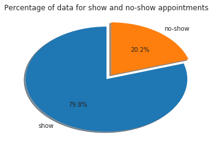

```python
# See the percentage of data in each category
perc_noshow = df_age_no_show.count() / (df_age_no_show.count() + df_age_show.count())
perc_show = df_age_show.count() / (df_age_no_show.count() + df_age_show.count())
plt.pie([perc_show, perc_noshow],explode = (0, 0.1),labels=['show','no-show'], autopct='%1.1f%%',
        shadow=True, startangle=90)
plt.title('Percentage of data for show and no-show appointments')
plt.show()
```

*Age plays an important role for appointments, the Mean values for No-Show: 34 and Show: 37.*

*The age group between 35 to 70 shows up for appointment.*

### Question 2: How does patient's medical history, lifestyle, physical fitness affects appointments?

#### Medical history includes patients hypertension and diabetes, lifestyle reflects whether a patient is alcoholic or not, and patient current physical handicap status.

```python
# compare the appointments for show and no-show based on different parameters

def compare_appointments(_show_df, _no_show_df, labels, xlabel, ylabel, title):
    param = np.array([_show_df,_no_show_df])
    plt.hist(param, label=labels)
    plt.xticks(np.arange(2), ('No','Yes'))
    plt.xlabel(xlabel)
    plt.ylabel(ylabel)
    plt.title(title)
    plt.legend()
    plt.show()
```

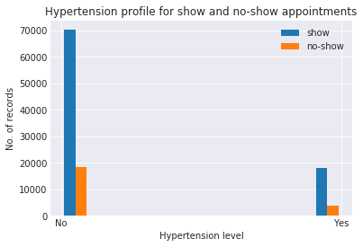

```python
# Hypertension profile

label=['show', 'no-show']
xlabel = "Hypertension level"
ylabel = "No. of records"
title = "Hypertension profile for show and no-show appointments"

compare_appointments(_show_df=all_shows["hypertension"], _no_show_df=all_no_shows["hypertension"],
                     labels=label, xlabel=xlabel, ylabel=ylabel, title=title)
```

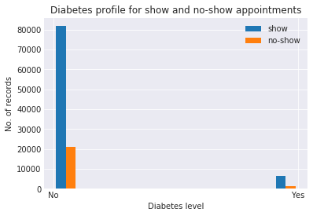

```python
# Diabetes profile

label=['show', 'no-show']
xlabel = "Diabetes level"
ylabel = "No. of records"
title = "Diabetes profile for show and no-show appointments"

compare_appointments(_show_df=all_shows["diabetes"], _no_show_df=all_no_shows["diabetes"],
                     labels=label, xlabel=xlabel, ylabel=ylabel, title=title)
```

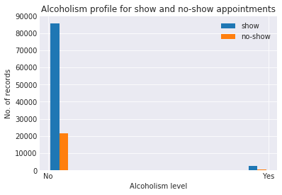

```python
# Alcoholism profile

label=['show', 'no-show']
xlabel = "Alcoholism level"
ylabel = "No. of records"
title = "Alcoholism profile for show and no-show appointments"

compare_appointments(_show_df=all_shows["alcoholism"], _no_show_df=all_no_shows["alcoholism"],
                     labels=label, xlabel=xlabel, ylabel=ylabel, title=title)
```

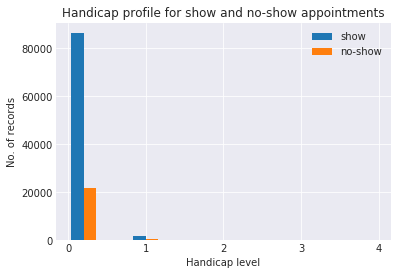

```python
# Handicap profile

handicap = [all_shows["handicap"], all_no_shows["handicap"]]
plt.hist(handicap,label=['show', 'no-show'])
plt.xticks(np.arange(5), ('0','1','2','3','4'))
plt.xlabel("Handicap level")
plt.ylabel("No. of records")
plt.title("Handicap profile for show and no-show appointments")
plt.legend()
plt.show()
```

> After performing the comparision between the show and no-show appointments, we can see that there are more patients with *"No-diabetes, No-hypertension, and No-alcoholism"* & also the handicap level with disability level 0 are more.

#### Let's see the distribution of medical history (hypertension and diabetes), & lifestyle for patients with show and no-show appointments

```python
# get the count of no. of records for patientsbased on specific parameter (diabetic, hypertension, etc...)

def get_parameter_count(_df, param):
    _zero_count = _df[param].where(_df[param]==0).count()
    _one_count  = _df[param].where(_df[param]==1).count()
    return _zero_count, _one_count

# visualize the results as pie plot

def visualize_perct_count(data_list, explode, labels, title):
    plt.pie(data_list, explode=explode, labels=labels, autopct='%1.1f%%', shadow=True)
    plt.title(title)
    plt.show()
```

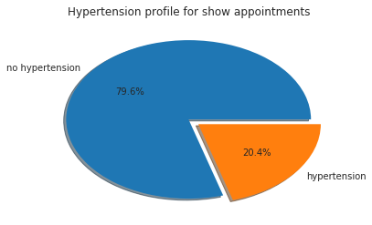

```python
# Hypertension profile for show appointments

hyper_show0, hyper_show1 = get_parameter_count(all_shows, "hypertension")
explode = (0, 0.1)
title = "Hypertension profile for show appointments"
visualize_perct_count([hyper_show0, hyper_show1], explode=explode, labels=["no hypertension" , "hypertension"],title=title )
```

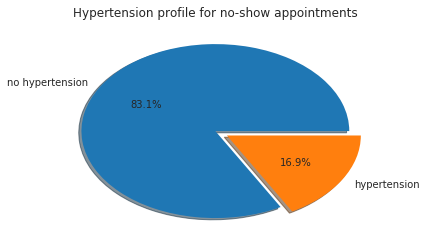

```python
# Hypertension profile for no-show appointments

hyper_no_show0, hyper_no_show1 = get_parameter_count(all_no_shows, "hypertension")
explode = (0, 0.1)
title = "Hypertension profile for no-show appointments"
visualize_perct_count([hyper_no_show0, hyper_no_show1], explode=explode,
                      labels=["no hypertension" , "hypertension"],title=title )
```

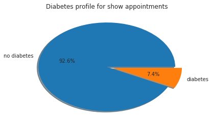

```python
# Diabetes profile for show appointments

diab_show0, diab_show1 = get_parameter_count(all_shows, "diabetes")
explode = (0, 0.1)
title = "Diabetes profile for show appointments"
visualize_perct_count([diab_show0, diab_show1], explode=explode, labels=["no diabetes" , "diabetes"],title=title )
```

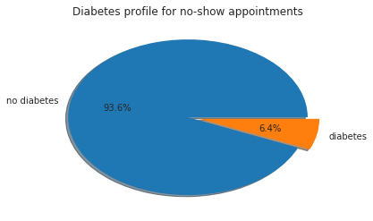

```python
# Diabetes profile for no-show appointments

diab_no_show0, diab_no_show1 = get_parameter_count(all_no_shows, "diabetes")
explode = (0, 0.1)
title = "Diabetes profile for no-show appointments"
visualize_perct_count([diab_no_show0, diab_no_show1], explode=explode, labels=["no diabetes" , "diabetes"],title=title )
```

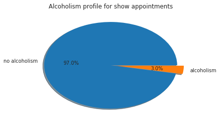

```
no alcoholism  85525  alcoholism 2683
```

```python
# Alcoholism profile for show appointments

alco_show0, alco_show1 = get_parameter_count(all_shows, "alcoholism")
explode = (0, 0.1)
title = "Alcoholism profile for show appointments"
visualize_perct_count([alco_show0, alco_show1], explode=explode, labels=["no alcoholism" , "alcoholism"],title=title )

print("no alcoholism " , alco_show0, " alcoholism", alco_show1)
```

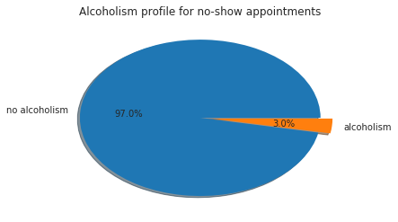

```
no alcoholism  21642  alcoholism 677
```

```python
# Alcoholism profile for no-show appointments

alco_no_show0, alco_no_show1 = get_parameter_count(all_no_shows, "alcoholism")
explode = (0, 0.1)
title = "Alcoholism profile for no-show appointments"
visualize_perct_count([alco_no_show0, alco_no_show1], explode=explode, labels=["no alcoholism" , "alcoholism"],title=title )

print("no alcoholism " , alco_no_show0, " alcoholism", alco_no_show1)
```

> The inference from above results shows that the alcoholism percentage for both show and no-show appointments are same. While the diabetic profile is almost same with ~1% difference and the hypertension profile has ~3.5% difference between show and no-show appointments.

### Question 3: Which neighborhoods have the highest number of no-shows?

```python
# get the influence in neighborhood

def get_influence(_df):
    influence_df = _df.groupby("neighborhood")["no_show"].count()
    return influence_df
```

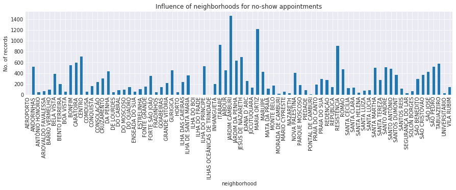

```python
# Influence of neighborhoods for no-show appointments

n_df = get_influence(all_no_shows)
n_df.plot(kind='bar', figsize=(15, 3),title="Influence of neighborhoods for no-show appointments")
plt.ylabel("No. of records")
plt.show()
```

> Top 5 no-show appointments neighborhood

```python
# See the top no-show appointments by sorting the items in descending order

n_df.sort_values(ascending=False).head()
```

```
neighborhood
JARDIM CAMBURI    1465
MARIA ORTIZ       1219
ITARARÉ            923
RESISTÊNCIA        906
CENTRO             703
Name: no_show, dtype: int64
```

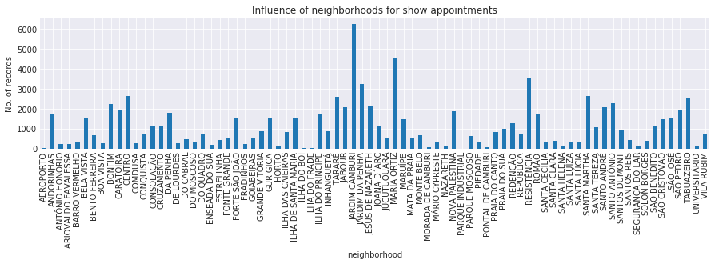

```python
# Influence of neighborhoods for show appointments

s_df = get_influence(all_shows)
s_df.plot(kind='bar', figsize=(15, 3),title="Influence of neighborhoods for show appointments")
plt.ylabel("No. of records")
plt.show()
```

> Top 5 show appointments neighborhood

```python
# See the top show appointments by sorting the items in descending order

s_df.sort_values(ascending=False).head()
```

```
neighborhood
JARDIM CAMBURI     6252
MARIA ORTIZ        4586
RESISTÊNCIA        3525
JARDIM DA PENHA    3246
SANTA MARTHA       2635
Name: no_show, dtype: int64
```

### Question 4: What is the trend of no-shows vs shows by patients that received SMS reminders?

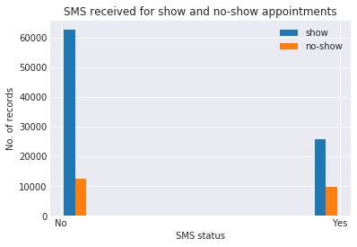

```python
# sms message received by patients

label = ['show', 'no-show']
xlabel = "SMS status"
ylabel = "No. of records"
title = "SMS received for show and no-show appointments"

compare_appointments(_show_df=all_shows["sms_received"], _no_show_df=all_no_shows["sms_received"],
                     labels=label, xlabel=xlabel, ylabel=ylabel, title=title)
```

> Comparision of show and no-show appointments based on SMS message. Most no. of patients didn't received SMS.

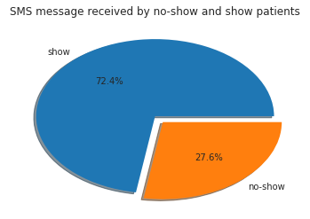

```
show  25698  no-show 9784
```

```python
# Calculate the percentage of patients who received sms

count_sms_no_show = all_no_shows["sms_received"].where(all_no_shows["sms_received"]==1).count()
count_sms_show = all_shows["sms_received"].where(all_shows["sms_received"]==1).count()
explode = (0, 0.1)
title = "SMS message received by no-show and show patients"
visualize_perct_count([count_sms_show, count_sms_no_show], explode=explode, labels=["show" , "no-show"],title=title )
print("show " , count_sms_show, " no-show", count_sms_no_show )
```

> Patients who received an SMS had a no-show percentage of 27.6% and show percentage of 72.4%

### Question 5: Does difference between schedule date and appointment date results in no-shows?

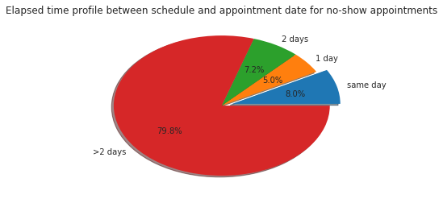

```python
# Calculate the elapsed time between schedule and appointment date for no-show appointments

no_show_same_day = all_no_shows["elapsed_days"].where(all_no_shows["elapsed_days"]=="0 days").count()
no_show_1day = all_no_shows["elapsed_days"].where(all_no_shows["elapsed_days"]=="1 days").count()
no_show_2day = all_no_shows["elapsed_days"].where(all_no_shows["elapsed_days"]=="2 days").count()
no_show_more_than_2_day = all_no_shows["elapsed_days"].count() - (no_show_same_day+no_show_1day+no_show_2day)

explode = (0.1, 0, 0, 0)
no_show_items = [no_show_same_day, no_show_1day, no_show_2day, no_show_more_than_2_day]
labels=["same day", "1 day", "2 days", ">2 days"]
title = "Elapsed time profile between schedule and appointment date for no-show appointments"
visualize_perct_count(no_show_items, explode=explode, labels=labels,title=title)
```

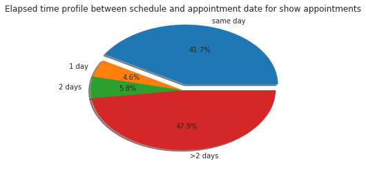

```python
# Calculate the elapsed time between schedule and appointment date for show appointments

show_same_day = all_shows["elapsed_days"].where(all_shows["elapsed_days"]=="0 days").count()
show_1day = all_shows["elapsed_days"].where(all_shows["elapsed_days"]=="1 days").count()
show_2day = all_shows["elapsed_days"].where(all_shows["elapsed_days"]=="2 days").count()
show_more_than_2_day = all_shows["elapsed_days"].count() - (show_same_day + show_1day + show_2day)

explode = (0.1, 0, 0, 0)
show_items = [show_same_day, show_1day, show_2day, show_more_than_2_day]
labels=["same day", "1 day", "2 days", ">2 days"]
title = "Elapsed time profile between schedule and appointment date for show appointments"
visualize_perct_count(show_items, explode=explode, labels=labels,title=title)
```

> Patients who have scheduled the appointment on same day and appeared (show) are 41.7% and

> only 8% patients didn't appeared (no-show appointments) on same day

### Question 6: Are patients failing to appear on specific days of the week?

```python
# histogram based on the days of week for appointments

def appointmemts_dow(_df):
    _mon = _df.query('appointment_dow == "Monday"').count()
    _tue = _df.query('appointment_dow == "Tuesday"').count()
    _wed = _df.query('appointment_dow == "Wednesday"').count()
    _thu = _df.query('appointment_dow == "Thursday"').count()
    _fri = _df.query('appointment_dow == "Friday"').count()
    _sat = _df.query('appointment_dow == "Saturday"').count()
    _sun = _df.query('appointment_dow == "Sunday"').count()

    _days_of_week = [_mon["appointment_dow"], _tue["appointment_dow"], _wed["appointment_dow"],
                 _thu["appointment_dow"], _fri["appointment_dow"], _sat["appointment_dow"], _sun["appointment_dow"]]

    position = [1, 2, 3, 4, 5, 6, 7]

    labels = ['Monday','Tuesday','Wednesday','Thursday','Friday','Saturday','Sunday']

    return _days_of_week, position, labels
```

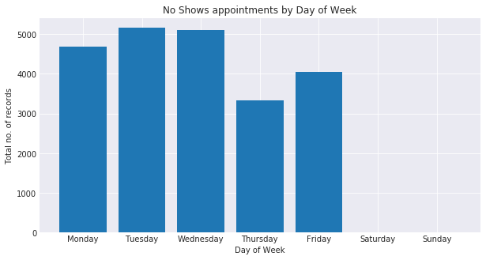

```python
# No-shows appointments by day of week

_days_of_week, position, labels = appointmemts_dow(_df=all_no_shows)

plt.bar(position, _days_of_week, tick_label=labels)
plt.title('No Shows appointments by Day of Week')
plt.xlabel('Day of Week')
plt.ylabel('Total no. of records')
fig = plt.gcf()
fig.set_size_inches(10,5);
```

> Most no-shows appointments were on Tuesdays.

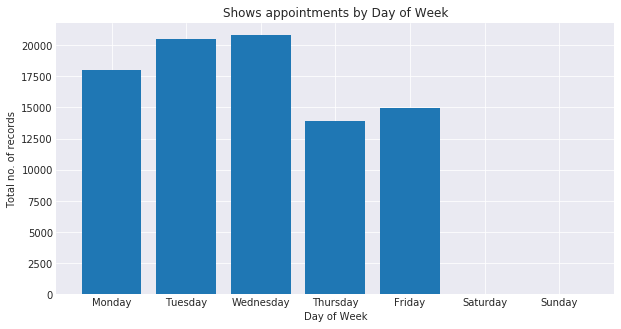

```python
# Shows appointments by day of week

_days_of_week, position, labels = appointmemts_dow(_df=all_shows)

plt.bar(position, _days_of_week, tick_label=labels)
plt.title('Shows appointments by Day of Week')
plt.xlabel('Day of Week')
plt.ylabel('Total no. of records')
fig = plt.gcf()
fig.set_size_inches(10,5);
```

> Most patients show for appointment on Wednesdays.

### Question 7: Which gender group generally don't show-up on appointment day ?

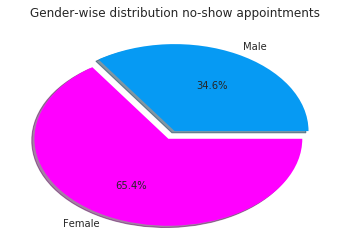

```python
# Gender-wise distribution no-show appointments

_F = all_no_shows["gender"].where(all_no_shows["gender"]=="F").count()
_M = all_no_shows["gender"].where(all_no_shows["gender"]=="M").count()
explode = (0, 0.1)
plt.pie([_M, _F],explode=explode,labels=["Male","Female"], colors=["xkcd:azure","fuchsia"], autopct='%1.1f%%', shadow=True)
plt.title("Gender-wise distribution no-show appointments")
plt.show()
```

> 65.4% of patients who didn't show up on appointment date were females.

## Conclusions

This exploratory analysis was able to correlate schedule day and appointment day, appointment sms reminders, neighborhood, and medical history.

#### Findings:

Q1. Does age play a role that whether or not patient show up for their appointment?

Age plays an important role for appointments, the Mean values for No-Show: 34 and Show: 37. The age group between 35 to 70 shows up for appointment.

Q2. How does patient's medical history, lifestyle, physical fitness affects appointments?

The inference from above analysis shows that the alcoholism percentage for both show and no-show appointments are same. While the diabetic profile is almost same with ~1% difference and the hypertension profile has ~3.5% difference between show and no-show appointments.

Q3. Which neighborhoods have the highest number of no-shows?

Top 5 no-show appointments neighborhood

1. JARDIM CAMBURI 1465
2. MARIA ORTIZ 1219
3. ITARARÉ 923
4. RESISTÊNCIA 906
5. CENTRO 703

Q4. What is the trend of no-shows vs shows by patients that received SMS reminders?

Patients who received an SMS had a no-show percentage of 27.6% and show percentage of 72.4%

Q5. Does difference between schedule date and appointment date results in no-shows?

Patients who have scheduled the appointment on same day and appeared (show) are 41.7% and only 8% patients didn't appeared (no-show appointments) on same day

Q6. Are patients failing to appear on specific days of the week?

Most no-shows appointments were on Tuesdays.

Q7. Which gender group generally don't show-up on appointment day ?

65.4% of patients who didn't show up on appointment date were females.

#### Limitations:

1. Information regarding the appointment if given like the medical condition for which patient wants to counsult the doctor.
2. It would be interesting to know why some patients received an SMS. If these patients had habit of not showing up in previous appointments it would explain the no-show percentage.

```python
from subprocess import call
call(['python', '-m', 'nbconvert', 'Investigate_a_Dataset.ipynb'])
```

```
0
```